# Task 1

$g_{1}^{PD}(z) = E_{X_2}f(X_{1|=z}) = E_{X_2}(z + x_2)^2 = E_{X_2}z^2 + 2E_{X_2} zx_2 + E_{X_2}x_2^2 = z^2 + 0 + E_{X_2}x_2^2 = z^2 + \frac{1}{2}\int_{-1}^1 x^2 dx = z^2 + \frac{1}{3}$

$g_{1}^{MP}(z) = E_{X_2|x_1 = z}f(X_{1|=z}) = E_{X_2|x_1 = z}(z + x_2)^2 = E_{X_2|x_1 = z}z^2 + 2E_{X_2|x_1 = z} zx_2 + E_{X_2|x_1 = z}x_2^2 = z^2 + 2z^2 + z^2 = 4z^2$

$g_{1}^{AL}(z) = \int_{-1}^z [E_{X_2|x_1 = v}\frac{\partial f(x)}{\partial x_1}]dv = \int_{-1}^z [E_{X_2|x_1 = v}[2x_1 + 2x_2]]dv = \int_{-1}^z [2E_{X_2|x_1 = v}x_1 + 2E_{X_2|x_1 = v}x_2]dv = \int_{-1}^z 4v dv = 2z^2 + c$

# Task 2

## Subtask 0: Train model

For my experiments, I used the Magic Telescope dataset, which is used to classify whether gamma radiation has been detected, based on advanced measurements. All variables in this dataset are continuous.

|  | fLength: | fWidth: | fSize: | fConc: | fConc1: | fAsym: | fM3Long: | fM3Trans: | fAlpha: | fDist: | TARGET |
| --- | --- | --- | --- | --- | --- | --- | --- | --- | --- | --- | --- |
| 0 | 28.7967 | 16.0021 | 2.6449 | 0.3918 | 0.1982 | 27.7004 | 22.0110 | -8.2027 | 40.0920 | 81.8828 | g |
| 1 | 31.6036 | 11.7235 | 2.5185 | 0.5303 | 0.3773 | 26.2722 | 23.8238 | -9.9574 | 6.3609 | 205.2610 | g |
| 2 | 162.0520 | 136.0310 | 4.0612 | 0.0374 | 0.0187 | 116.7410 | -64.8580 | -45.2160 | 76.9600 | 256.7880 | g |
| 3 | 23.8172 | 9.5728 | 2.3385 | 0.6147 | 0.3922 | 27.2107 | -6.4633 | -7.1513 | 10.4490 | 116.7370 | g |
| 4 | 75.1362 | 30.9205 | 3.1611 | 0.3168 | 0.1832 | -5.5277 | 28.5525 | 21.8393 | 4.6480 | 356.4620 | g |
| ... | ... | ... | ... | ... | ... | ... | ... | ... | ... | ... | ... |
| 19015 | 21.3846 | 10.9170 | 2.6161 | 0.5857 | 0.3934 | 15.2618 | 11.5245 | 2.8766 | 2.4229 | 106.8258 | h |
| 19016 | 28.9452 | 6.7020 | 2.2672 | 0.5351 | 0.2784 | 37.0816 | 13.1853 | -2.9632 | 86.7975 | 247.4560 | h |
| 19017 | 75.4455 | 47.5305 | 3.4483 | 0.1417 | 0.0549 | -9.3561 | 41.0562 | -9.4662 | 30.2987 | 256.5166 | h |
| 19018 | 120.5135 | 76.9018 | 3.9939 | 0.0944 | 0.0683 | 5.8043 | -93.5224 | -63.8389 | 84.6874 | 408.3166 | h |
| 19019 | 187.1814 | 53.0014 | 3.2093 | 0.2876 | 0.1539 | -167.3125 | -168.4558 | 31.4755 | 52.7310 | 272.3174 | h |

19020 rows × 11 columns

On this data, I trained an XGBoost model with 100 estimators and a maximum depth of 3. Before training, I divided the set into training and test sets to then evaluate the model. I obtained an accuracy of 0.8723 and an AUC of 0.9318.

## Subtask 1: Calculate predictions

I chose two observations, the first positive and the second negative, to see how the model would behave. Below I show the observations I selected.

|  | fLength: | fWidth: | fSize: | fConc: | fConc1: | fAsym: | fM3Long: | fM3Trans: | fAlpha: | fDist: |
| --- | --- | --- | --- | --- | --- | --- | --- | --- | --- | --- |
| 0 | 28.7967 | 16.0021 | 2.6449 | 0.3918 | 0.1982 | 27.7004 | 22.0110 | -8.2027 | 40.092 | 81.8828 |
| 19019 | 187.1814 | 53.0014 | 3.2093 | 0.2876 | 0.1539 | -167.3125 | -168.4558 | 31.4755 | 52.731 | 272.3174 |

The model classified both cases correctly, for the first I got a prediction of 0.816 and for the second I got a prediction of 0.0006.

## Subtask 2: Ceteris Paribus

I have calculated Ceteris Paribus profiles for the first observation and displayed the plots for the variables fLength and fSize below:

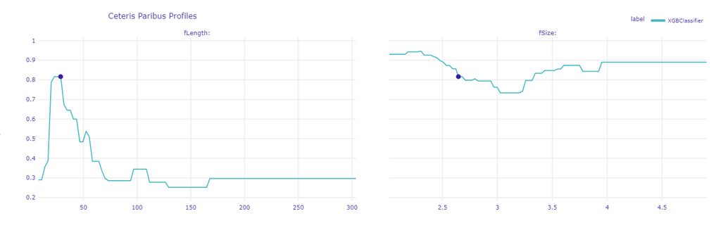

We can see that the value of the variable fLength had a strong influence on this prediction. If it had been closer to zero or greater the model would not have classified this measurement as gamma radiation. The variable fSize did not have as much influence. The model prediction would have been positive for any value.

I made analogous diagrams for the last observation:

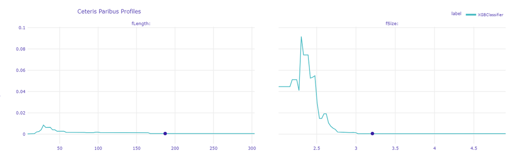

Note that, in this case, the value of the variable fLength did not have much influence on the prediction, as it would always be negative for fixed other values. The prediction would change strongly if the value of fSize was very small.

## Subtask 3: Different CP profiles

Above I have shown that for different observations the profiles can differ. Now I will also show that they can differ for two observations with similar prediction values. Below I show the plots for observations of numbers 3 and 4 (you can see those observations in the table above):

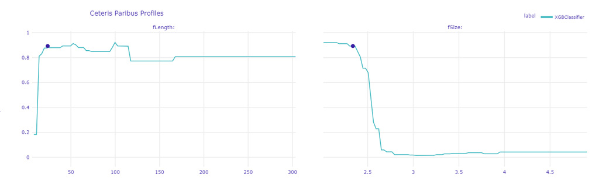

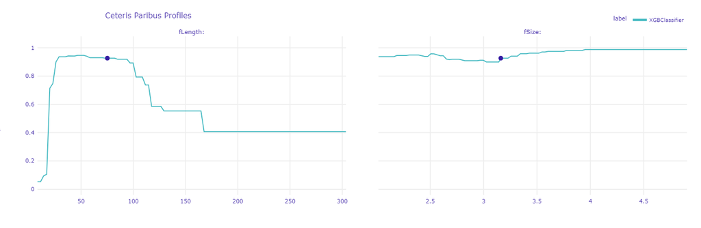

For the third observation, increasing fLength would not change the prediction, but increasing fSize would drastically reduce it. For the fourth observation, the opposite is true.

## Subtask 4: CP and PDP comparison

Below I present the shared CP plots for the first 10 observations and the PDP charts (global explanations):

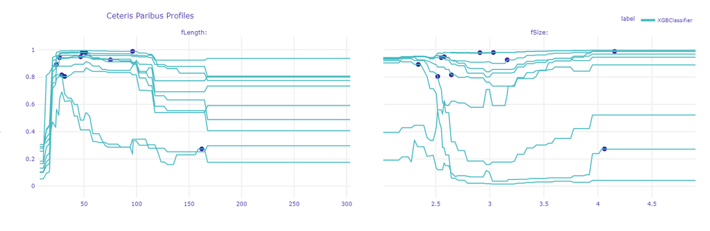

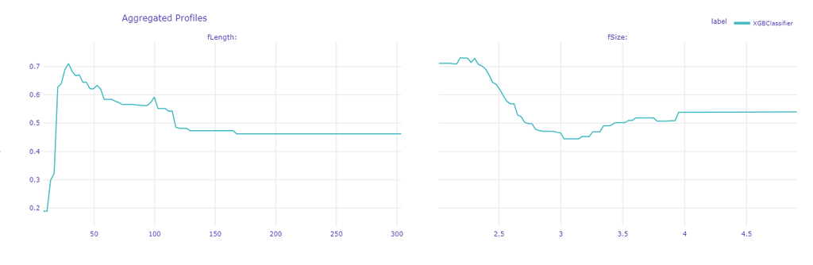

## Subtask 5: PDP for different models

I trained a second model, Random Forest, on the same dataset and made PDP plots for it for the same variables as above:

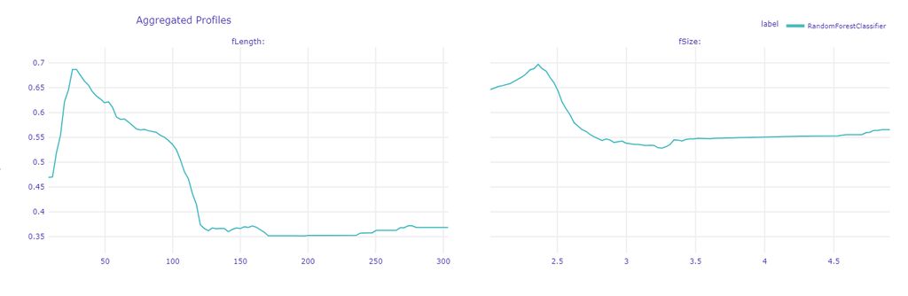

# Appendix

```python
!pip install dalex
!pip install alibi
```

[output not shown]

```python
import dalex as dx
import xgboost
import alibi
import sklearn
import pandas as pd
import numpy as np
import matplotlib.pyplot as plt
from sklearn.metrics import roc_auc_score, accuracy_score
from sklearn.model_selection import train_test_split
from sklearn.ensemble import RandomForestClassifier
```

```python
df = pd.read_csv('MagicTelescope.csv').dropna()

X = df.drop(columns='TARGET').iloc[:,1:]
y = (df.TARGET == "g")

X_train, X_test, y_train, y_test = train_test_split(X, y, test_size=0.25, random_state=17)
```

```python
model = xgboost.XGBClassifier(
    n_estimators=100,
    max_depth=3,
    use_label_encoder=False,
    eval_metric="logloss",
)

model.fit(X_train, y_train)
```

```
XGBClassifier(base_score=None, booster=None, callbacks=None,
              colsample_bylevel=None, colsample_bynode=None,
              colsample_bytree=None, device=None, early_stopping_rounds=None,
              enable_categorical=False, eval_metric='logloss',
              feature_types=None, gamma=None, grow_policy=None,
              importance_type=None, interaction_constraints=None,
              learning_rate=None, max_bin=None, max_cat_threshold=None,
              max_cat_to_onehot=None, max_delta_step=None, max_depth=3,
              max_leaves=None, min_child_weight=None, missing=nan,
              monotone_constraints=None, multi_strategy=None, n_estimators=100,
              n_jobs=None, num_parallel_tree=None, random_state=None, ...)
```

```python
explainer = dx.Explainer(model, X_test, y_test)
explainer.model_performance(cutoff=y.mean())
```

```
Preparation of a new explainer is initiated

  -> data              : 4755 rows 10 cols
  -> target variable   : Parameter 'y' was a pandas.Series. Converted to a numpy.ndarray.
  -> target variable   : 4755 values
  -> model_class       : xgboost.sklearn.XGBClassifier (default)
  -> label             : Not specified, model's class short name will be used. (default)
  -> predict function  : <function yhat_proba_default at 0x7b480a4df010> will be used (default)
  -> predict function  : Accepts pandas.DataFrame and numpy.ndarray.
  -> predicted values  : min = 1.88e-05, mean = 0.655, max = 0.998
  -> model type        : classification will be used (default)
  -> residual function : difference between y and yhat (default)
  -> residuals         : min = -0.99, mean = -0.0143, max = 0.993
  -> model_info        : package xgboost

A new explainer has been created!
```

|  | recall | precision | f1 | accuracy | auc |
| --- | --- | --- | --- | --- | --- |
| XGBClassifier | 0.908733 | 0.893768 | 0.901188 | 0.872345 | 0.931852 |

```python
observation1 = X.iloc[[0]]
print(explainer.predict(observation1))
observation2 = X.iloc[[-1]]
print(explainer.predict(observation2))
```

```
[0.8160999]
[0.00057204]
```

```python
cp1 = explainer.predict_profile(new_observation=observation1)
cp2 = explainer.predict_profile(new_observation=observation2)
```

```python
cp1.plot(variables=["fLength:", "fSize:"])
```

```python
cp2.plot(variables=["fLength:", "fSize:"])
```

```python
observation3 = X.iloc[[3]]
observation4 = X.iloc[[4]]
cp3 = explainer.predict_profile(new_observation=observation3)
cp4 = explainer.predict_profile(new_observation=observation4)
```

```python
cp3.plot(variables=["fLength:", "fSize:"])
```

```python
cp4.plot(variables=["fLength:", "fSize:"])
```

```python
pdp = explainer.model_profile()
```

```python
pdp.plot(variables=["fLength:", "fSize:"])
```

```python
cp_10 = explainer.predict_profile(new_observation=X.iloc[0:10])
cp_10.plot(variables=["fLength:", "fSize:"])
```

```python
forest = RandomForestClassifier(n_estimators=100, random_state=0)
forest.fit(X_train, y_train)
```

```
RandomForestClassifier(random_state=0)
```

```python
explainer_forest = dx.Explainer(forest, X_test, y_test)
```

```
Preparation of a new explainer is initiated

  -> data              : 4755 rows 10 cols
  -> target variable   : Parameter 'y' was a pandas.Series. Converted to a numpy.ndarray.
  -> target variable   : 4755 values
  -> model_class       : sklearn.ensemble._forest.RandomForestClassifier (default)
  -> label             : Not specified, model's class short name will be used. (default)
  -> predict function  : <function yhat_proba_default at 0x7b480a4df010> will be used (default)
  -> predict function  : Accepts pandas.DataFrame and numpy.ndarray.
```

```
  -> predicted values  : min = 0.0, mean = 0.652, max = 1.0
  -> model type        : classification will be used (default)
  -> residual function : difference between y and yhat (default)
  -> residuals         : min = -1.0, mean = -0.0118, max = 0.96
  -> model_info        : package sklearn

A new explainer has been created!
```

```python
pdp_forest =  explainer_forest.model_profile()
```

```python
pdp_forest.plot(variables=["fLength:", "fSize:"])
```

[interactive chart not shown]

## Convert

```python
%%shell
jupyter nbconvert --to html --template=classic /content/Homework5.ipynb
```